# TCGAbiolinks lecture

In this lecture we will go over how to install and use the package TCGAbiolinks for querying, downloading, and analyzing publicly available TCGA cancer data.

# Installation

You **must** have the latest version of R, Bioconductor BiocManager, and TCGAbiolinks installed for the package to work correctly. Check your R version by running the command `version` in the console. If it is earlier than 3.6.1, please [re-install R](https://cran.r-project.org/mirrors.html). Select a mirror, then choose the correct installer for your system.

Install BiocManager and TCGAbiolinks:

```r
if (!requireNamespace("BiocManager", quietly = TRUE))
    install.packages("BiocManager")

BiocManager::install("TCGAbiolinks")
```

While on campus, you need to set proxies in order to “talk” to the database

```r
Sys.setenv(http_proxy="proxy.swmed.edu:3128")
Sys.setenv(https_proxy="proxy.swmed.edu:3128")
```

Load the pacakge and set your working directory

```r
library(TCGAbiolinks)

setwd("~/r_nanocourse_2020/")
```

# TCGAbiolinks

## Queries

Queries are the most important part of the TCGAbiolinks package. Crafting a good query will allow you to find and download the desired data from the correct TCGA project. You may reference the [user guide](http://bioconductor.org/packages/release/bioc/vignettes/TCGAbiolinks/inst/doc/index.html) at any time for more information.

You can view a list of available projects by running the following command:

```r
getGDCprojects()
```

|  | dbgap_accession_number | disease_type | releasable | released | state | primary_site | project_id | id | name | tumor |
| --- | --- | --- | --- | --- | --- | --- | --- | --- | --- | --- |
| 1 | NA |  | FALSE | TRUE | open |  | TCGA-SARC | TCGA-SARC | Sarcoma | SARC |
| 2 | phs000466 |  | FALSE | TRUE | open |  | TARGET-CCSK | TARGET-CCSK | Clear Cell Sarcoma of the Kidney | CCSK |
| 3 | phs000467 |  | TRUE | TRUE | open |  | TARGET-NBL | TARGET-NBL | Neuroblastoma | NBL |
| 4 | phs000465 |  | TRUE | TRUE | open |  | TARGET-AML | TARGET-AML | Acute Myeloid Leukemia | AML |
| 5 | NA |  | FALSE | TRUE | open |  | TCGA-MESO | TCGA-MESO | Mesothelioma | MESO |
| 6 | NA |  | FALSE | TRUE | open |  | TCGA-ACC | TCGA-ACC | Adrenocortical Carcinoma | ACC |
| 7 | NA |  | FALSE | TRUE | open |  | TCGA-READ | TCGA-READ | Rectum Adenocarcinoma | READ |
| 8 | NA |  | FALSE | TRUE | open |  | TCGA-LGG | TCGA-LGG | Brain Lower Grade Glioma | LGG |
| 9 | phs001628 |  | FALSE | TRUE | open |  | BEATAML1.0-CRENOLANIB | BEATAML1.0-CRENOLANIB | Clinical Resistance to Crenolanib in Acute Myeloid Leukemia Due to Diverse Molecular Mechanisms | CRENOLANIB |
| 10 | NA |  | FALSE | TRUE | open |  | TCGA-THCA | TCGA-THCA | Thyroid Carcinoma | THCA |

[output cut: 53 more lines]

The command for crafting queries is `GDCquery()`. Use `?GDCquery` to view the command arguments. Not all arguments are required, but the more detailed your query, the more specific results you will receive.

After selecting a project, use `getProjectSummary(project)` to view available data categories.

```r
TCGAbiolinks:::getProjectSummary("TCGA-COAD")
```

|  | case_count | file_count | data_category |
| --- | --- | --- | --- |
| 1 | 459 | 2493 | Transcriptome Profiling |
| 2 | 460 | 1953 | Copy Number Variation |
| 3 | 433 | 3952 | Simple Nucleotide Variation |
| 4 | 458 | 556 | DNA Methylation |
| 5 | 461 | 531 | Clinical |
| 6 | 460 | 2000 | Sequencing Reads |
| 7 | 461 | 2835 | Biospecimen |

```
$case_count
[1] 461

$file_count
[1] 14320

$file_size
[1] 2.747049e+13
```

You can view available “sample.types” and “data.types” [here](http://bioconductor.org/packages/release/bioc/vignettes/TCGAbiolinks/inst/doc/query.html).

Let’s craft a query to download CNV data for project LUAD.

```r
query <- GDCquery(project="TCGA-LUAD", data.category = "Copy Number Variation",
                  sample.type = "Primary solid Tumor", data.type = "Copy Number Segment")
```

Please note that capital letters and spelling of categories must match the database *exactly*. Sometimes the package lets you know that something is not correct, but not for all options. Here’s an example with misspelled sample types and data types.

```r
query <- GDCquery(project="TCGA-LUAD", data.category = "Copy Number Variation",
                  sample.type = "Primary Solid Tumor", data.type = "Copy Number Segment")
```

```
--------------------------------------
o GDCquery: Searching in GDC database
--------------------------------------
Genome of reference: hg38
```

| tissue.code | shortLetterCode | tissue.definition |
| --- | --- | --- |
| 01 | TP | Primary solid Tumor |
| 02 | TR | Recurrent Solid Tumor |
| 03 | TB | Primary Blood Derived Cancer - Peripheral Blood |
| 04 | TRBM | Recurrent Blood Derived Cancer - Bone Marrow |
| 05 | TAP | Additional - New Primary |
| 06 | TM | Metastatic |
| 07 | TAM | Additional Metastatic |
| 08 | THOC | Human Tumor Original Cells |
| 09 | TBM | Primary Blood Derived Cancer - Bone Marrow |
| 10 | NB | Blood Derived Normal |
| 11 | NT | Solid Tissue Normal |
| 12 | NBC | Buccal Cell Normal |
| 13 | NEBV | EBV Immortalized Normal |
| 14 | NBM | Bone Marrow Normal |
| 20 | CELLC | Control Analyte |
| 40 | TRB | Recurrent Blood Derived Cancer - Peripheral Blood |
| 50 | CELL | Cell Lines |
| 60 | XP | Primary Xenograft Tissue |
| 61 | XCL | Cell Line Derived Xenograft Tissue |

```
Error in checkBarcodeDefinition(sample.type) :
  Primary Solid Tumor was not found. Please select a difinition from the table above
```

```r
query <- GDCquery(project="TCGA-LUAD", data.category = "Copy Number Variation",
                  sample.type = "Primary solid Tumor", data.type = "Copy number Segment")
```

```
--------------------------------------
o GDCquery: Searching in GDC database
--------------------------------------
Genome of reference: hg38
```

| sort(harmonized.data.type) |
| --- |
| Aggregated Somatic Mutation |
| Annotated Somatic Mutation |
| Biospecimen Supplement |
| Clinical Supplement |
| Copy Number Segment |
| Gene Expression Quantification |
| Gene Level Copy Number Scores |
| Isoform Expression Quantification |
| Masked Copy Number Segment |
| Masked Somatic Mutation |
| Masked Somatic Mutation |
| Methylation Beta Value |
| miRNA Expression Quantification |
| Raw CGI Variant |
| Raw Simple Somatic Mutation |
| Slide Image |
| Splice Junction Quantification |

```
Error in checkDataTypeInput(legacy = legacy, data.type = data.type) :
  Please set a data.type argument from the column harmonized.data.type above
```

## Downloading the data

After crafting a successful query, you can check the results to see what samples are included and the file names to be downloaded.

```r
query <- GDCquery(project="TCGA-LUAD", data.category = "Copy Number Variation",
                  sample.type = "Primary solid Tumor", data.type = "Copy Number Segment")
```

```
--------------------------------------
o GDCquery: Searching in GDC database
--------------------------------------
Genome of reference: hg38
--------------------------------------------
oo Accessing GDC. This might take a while...
--------------------------------------------
ooo Project: TCGA-LUAD
--------------------
oo Filtering results
--------------------
ooo By data.type
ooo By sample.type
----------------
oo Checking data
----------------
ooo Check if there are duplicated cases
ooo Check if there results for the query
-------------------
o Preparing output
-------------------
```

```r
query$results[[1]]
```

|  | data_release | data_type | updated_datetime | file_name | submitter_id | file_id | file_size | cases | id | created_datetime | md5sum | data_format | access | platform | state | version | data_category | type | experimental_strategy | project | analysis_id | analysis_updated_datetime | analysis_created_datetime | analysis_submitter_id | analysis_state | analysis_workflow_link | analysis_workflow_type | analysis_workflow_version | tissue.definition |
| --- | --- | --- | --- | --- | --- | --- | --- | --- | --- | --- | --- | --- | --- | --- | --- | --- | --- | --- | --- | --- | --- | --- | --- | --- | --- | --- | --- | --- | --- |
| 1 | 12.0 - 21.0 | Copy Number Segment | 2019-09-18T01:23:46.147678+00:00 | NULLS_p_TCGA_183_185_186_SNP_N_GenomeWideSNP_6_C01_914340.grch38.seg.v2.txt | 3aba5d45-7ddc-4f06-9eb2-efa10b2a6455_dr12_allcnv | a2e4d6a7-905a-43c3-8b3b-3cfae18e6112 | 76814 | TCGA-44-7669-01A-21D-2062-01 | a2e4d6a7-905a-43c3-8b3b-3cfae18e6112 | 2018-05-18T16:55:37.503595-05:00 | 49d1c8d23e3acd7658a26d202663990f | TXT | open | Affymetrix SNP 6.0 | released | 1 | Copy Number Variation | copy_number_segment | Genotyping Array | TCGA-LUAD | a30d6b6f-059e-4952-9beb-2bb0b007de3c | 2018-09-06T21:10:41.393019-05:00 | 2016-05-03T01:28:53.589195-05:00 | 3aba5d45-7ddc-4f06-9eb2-efa10b2a6455_dnacopy | released | https://github.com/NCI-GDC/dnacopy-tool | DNAcopy | v1 | Primary solid Tumor |
| 2 | 12.0 - 21.0 | Copy Number Segment | 2019-09-18T01:23:46.147678+00:00 | LOOBY_p_TCGAb58_SNP_N_GenomeWideSNP_6_E05_680334.grch38.seg.v2.txt | f0d04d03-8429-4db3-a856-b5b9ccb8fd6d_dr12_allcnv | 59d3b4aa-b414-4aaf-9ff2-e13c84874ec6 | 30338 | TCGA-05-4418-01A-01D-1204-01 | 59d3b4aa-b414-4aaf-9ff2-e13c84874ec6 | 2018-05-18T16:55:37.503595-05:00 | d55b90954f3c7902cd492250d99949a9 | TXT | open | Affymetrix SNP 6.0 | released | 1 | Copy Number Variation | copy_number_segment | Genotyping Array | TCGA-LUAD | acfaab11-e6fc-417f-8e0a-a9ce336ef71c | 2018-09-06T21:10:41.393019-05:00 | 2016-05-03T04:26:42.639060-05:00 | f0d04d03-8429-4db3-a856-b5b9ccb8fd6d_dnacopy | released | https://github.com/NCI-GDC/dnacopy-tool | DNAcopy | v1 | Primary solid Tumor |
| 3 | 12.0 - 21.0 | Copy Number Segment | 2019-09-18T01:23:46.147678+00:00 | PALLS_p_TCGASNP_213_N_GenomeWideSNP_6_H07_1148206.grch38.seg.v2.txt | 60a08fa2-af61-403f-85e8-c9082f8c6252_dr12_allcnv | ab98d7dd-8df3-4d5b-b1c1-ea265c52a895 | 38789 | TCGA-99-8028-01A-11D-2237-01 | ab98d7dd-8df3-4d5b-b1c1-ea265c52a895 | 2018-05-18T16:55:37.503595-05:00 | 9a977fef45bdc530ca471f170c82b5fa | TXT | open | Affymetrix SNP 6.0 | released | 1 | Copy Number Variation | copy_number_segment | Genotyping Array | TCGA-LUAD | 95b0691c-cf49-4c60-96eb-a6c28f1541be | 2018-09-06T21:10:41.393019-05:00 | 2016-05-03T02:30:43.744121-05:00 | 60a08fa2-af61-403f-85e8-c9082f8c6252_dnacopy | released | https://github.com/NCI-GDC/dnacopy-tool | DNAcopy | v1 | Primary solid Tumor |
| 4 | 12.0 - 21.0 | Copy Number Segment | 2019-09-18T01:23:46.147678+00:00 | SHOWS_p_7TCGA_236_238_Mx_N_GenomeWideSNP_6_G08_1244668.grch38.seg.v2.txt | f2d0780c-eec9-4e7e-9bf6-18e89ddbea7d_dr12_allcnv | 7ed1e82e-c079-441d-838c-d5a712a1ff05 | 78415 | TCGA-91-8499-01A-11D-2389-01 | 7ed1e82e-c079-441d-838c-d5a712a1ff05 | 2018-05-18T16:55:37.503595-05:00 | 8aaf5e4522422bfb5004036b2efcee30 | TXT | open | Affymetrix SNP 6.0 | released | 1 | Copy Number Variation | copy_number_segment | Genotyping Array | TCGA-LUAD | 5a412c44-c1ce-4e37-b38f-41ec55104b0f | 2018-09-06T21:10:41.393019-05:00 | 2016-05-03T04:28:09.883231-05:00 | f2d0780c-eec9-4e7e-9bf6-18e89ddbea7d_dnacopy | released | https://github.com/NCI-GDC/dnacopy-tool | DNAcopy | v1 | Primary solid Tumor |
| 5 | 12.0 - 21.0 | Copy Number Segment | 2019-09-18T01:23:46.147678+00:00 | BURST_p_TCGA_b119_SNP_N_GenomeWideSNP_6_C01_787114.grch38.seg.v2.txt | 71a94de2-072b-439c-b19c-2dbb2d5aece5_dr12_allcnv | 5e03cd98-d9ea-470c-bba0-4358f73b881a | 60253 | TCGA-38-6178-01A-11D-1752-01 | 5e03cd98-d9ea-470c-bba0-4358f73b881a | 2018-05-18T16:55:37.503595-05:00 | c01c56f4843abfa83340a500cc16fa3a | TXT | open | Affymetrix SNP 6.0 | released | 1 | Copy Number Variation | copy_number_segment | Genotyping Array | TCGA-LUAD | b7382d94-0ab9-4248-a81b-671b144fb5f9 | 2018-09-06T21:10:41.393019-05:00 | 2016-05-03T02:43:58.723856-05:00 | 71a94de2-072b-439c-b19c-2dbb2d5aece5_dnacopy | released | https://github.com/NCI-GDC/dnacopy-tool | DNAcopy | v1 | Primary solid Tumor |
| 6 | 12.0 - 21.0 | Copy Number Segment | 2019-09-18T01:23:46.147678+00:00 | DUNGS_p_TCGA_b84_115_SNP_N_GenomeWideSNP_6_C12_771536.grch38.seg.v2.txt | ae9a8596-f4be-4877-a387-3cd83a7d7047_dr12_allcnv | d2a84045-54a5-482b-b741-c5d9d940f646 | 46757 | TCGA-05-5715-01A-01D-1624-01 | d2a84045-54a5-482b-b741-c5d9d940f646 | 2018-05-18T16:55:37.503595-05:00 | 706c69e4561ec1f342d4bf6bf45f416c | TXT | open | Affymetrix SNP 6.0 | released | 1 | Copy Number Variation | copy_number_segment | Genotyping Array | TCGA-LUAD | 67fac8c1-6ba7-4770-b342-dee3160c7572 | 2018-09-06T21:10:41.393019-05:00 | 2016-05-03T03:35:11.897249-05:00 | ae9a8596-f4be-4877-a387-3cd83a7d7047_dnacopy | released | https://github.com/NCI-GDC/dnacopy-tool | DNAcopy | v1 | Primary solid Tumor |
| 7 | 12.0 - 21.0 | Copy Number Segment | 2019-09-18T01:23:46.147678+00:00 | LOOBY_p_TCGAb58_SNP_N_GenomeWideSNP_6_F07_680338.grch38.seg.v2.txt | 30b0bcc2-81bc-4d10-b5a9-c2eb06bcfc04_dr12_allcnv | 98b6febc-1329-4f6a-80f5-73622513c2ce | 35867 | TCGA-05-4403-01A-01D-1204-01 | 98b6febc-1329-4f6a-80f5-73622513c2ce | 2018-05-18T16:55:37.503595-05:00 | 9f26c704927943d3363ad7e83bba50ad | TXT | open | Affymetrix SNP 6.0 | released | 1 | Copy Number Variation | copy_number_segment | Genotyping Array | TCGA-LUAD | aa221bca-b9e9-4a5d-93be-7a37dfff07b6 | 2018-09-06T21:10:41.393019-05:00 | 2016-05-03T01:05:52.816188-05:00 | 30b0bcc2-81bc-4d10-b5a9-c2eb06bcfc04_dnacopy | released | https://github.com/NCI-GDC/dnacopy-tool | DNAcopy | v1 | Primary solid Tumor |
| 8 | 12.0 - 21.0 | Copy Number Segment | 2019-09-18T01:23:46.147678+00:00 | BASIC_p_TCGASNP_219_221_223_N_GenomeWideSNP_6_E04_1148654.grch38.seg.v2.txt | 8b829b4a-b2ec-44c7-b467-42f7e5eb2ccc_dr12_allcnv | 827f652a-8ef5-442e-b8e6-d6dcd34f2466 | 48743 | TCGA-69-8255-01A-11D-2283-01 | 827f652a-8ef5-442e-b8e6-d6dcd34f2466 | 2018-05-18T16:55:37.503595-05:00 | 0b8d281f55a97b0a4bb146bc9ed67a33 | TXT | open | Affymetrix SNP 6.0 | released | 1 | Copy Number Variation | copy_number_segment | Genotyping Array | TCGA-LUAD | 317734da-3b0f-4c57-a39b-7eb31c0fcef1 | 2018-09-06T21:10:41.393019-05:00 | 2016-05-03T03:03:57.843113-05:00 | 8b829b4a-b2ec-44c7-b467-42f7e5eb2ccc_dnacopy | released | https://github.com/NCI-GDC/dnacopy-tool | DNAcopy | v1 | Primary solid Tumor |
| 9 | 12.0 - 21.0 | Copy Number Segment | 2019-09-18T01:23:46.147678+00:00 | BROSE_p_TCGASNP_195_196_197_N_GenomeWideSNP_6_H03_1039662.grch38.seg.v2.txt | 96cf0a8d-2ee1-49ee-976e-9d614abaef19_dr12_allcnv | b54b5c0e-0205-4160-b715-3f68d6d71a87 | 33554 | TCGA-86-7714-01A-12D-2166-01 | b54b5c0e-0205-4160-b715-3f68d6d71a87 | 2018-05-18T16:55:37.503595-05:00 | e01564a5dbf1b0a48a762c72ad5e77be | TXT | open | Affymetrix SNP 6.0 | released | 1 | Copy Number Variation | copy_number_segment | Genotyping Array | TCGA-LUAD | c3c745ae-32e3-4613-9460-a89c0bfb112b | 2018-09-06T21:10:41.393019-05:00 | 2016-05-03T03:14:53.553697-05:00 | 96cf0a8d-2ee1-49ee-976e-9d614abaef19_dnacopy | released | https://github.com/NCI-GDC/dnacopy-tool | DNAcopy | v1 | Primary solid Tumor |
| 10 | 12.0 - 21.0 | Copy Number Segment | 2019-09-18T01:23:46.147678+00:00 | CYANS_p_TCGAb_422_423_424_NSP_GenomeWideSNP_6_C10_1513816.grch38.seg.v2.txt | 23f064f3-3c52-4f58-90c3-abb7e927c351_dr12_allcnv | b404bc9b-08a9-485e-a45c-b4bb4d4090c1 | 44670 | TCGA-49-AARN-01A-21D-A40Z-01 | b404bc9b-08a9-485e-a45c-b4bb4d4090c1 | 2018-05-18T16:55:37.503595-05:00 | 335eaa0c6277eabc4cb0b066466ea6f9 | TXT | open | Affymetrix SNP 6.0 | released | 1 | Copy Number Variation | copy_number_segment | Genotyping Array | TCGA-LUAD | 32331234-9f77-4f34-9546-8dc6cae78e21 | 2018-09-06T21:10:41.393019-05:00 | 2016-05-03T00:30:29.010825-05:00 | 23f064f3-3c52-4f58-90c3-abb7e927c351_dnacopy | released | https://github.com/NCI-GDC/dnacopy-tool | DNAcopy | v1 | Primary solid Tumor |

[output cut: 544 more lines]

```r
GDCdownload(query, files.per.chunk = 7) #sometimes if there are many files to be downloaded, it is best to break the download into chunks
```

**Occassionally, the download will fail on the last file. It’s an ongoing issue, but just re-run the command and the last will be downloaded.**

## Preparing the data

After downloading, the data needs to be in a form we can work with. `GDCprepare` collects each individual file, reads it in, then combines them.

```r
luad.cnv.tumor <- GDCprepare(query)
```

```r
head(luad.cnv.tumor)
```

| GDC_Aliquot | Chromosome | Start | End | Num_Probes | Segment_Mean | Sample |
| --- | --- | --- | --- | --- | --- | --- |
| e950d7d9-06d5-48d7-925d-f63f8bcf34f7 | 1 | 62920 | 462795 | 18 | 0.3992 | TCGA-44-7669-01A-21D-2062-01 |
| e950d7d9-06d5-48d7-925d-f63f8bcf34f7 | 1 | 462894 | 1716055 | 197 | -0.1006 | TCGA-44-7669-01A-21D-2062-01 |
| e950d7d9-06d5-48d7-925d-f63f8bcf34f7 | 1 | 1716451 | 1731957 | 7 | 1.2218 | TCGA-44-7669-01A-21D-2062-01 |
| e950d7d9-06d5-48d7-925d-f63f8bcf34f7 | 1 | 1732392 | 12799143 | 6273 | -0.0775 | TCGA-44-7669-01A-21D-2062-01 |
| e950d7d9-06d5-48d7-925d-f63f8bcf34f7 | 1 | 12799250 | 16604834 | 2158 | 0.1908 | TCGA-44-7669-01A-21D-2062-01 |
| e950d7d9-06d5-48d7-925d-f63f8bcf34f7 | 1 | 16605031 | 16909725 | 74 | 0.4233 | TCGA-44-7669-01A-21D-2062-01 |

## Other data types

Let’s download some rna-seq data

```r
GDCdownload(query.norm)
```

[output not shown]

```
Downloading data for project TCGA-CHOL
Of the 9 files for download 9 already exist.
All samples have been already downloaded
```

```r
chol.tum <- GDCprepare(query.tum)
```

```r
chol.tum <- GDCprepare(query.tum)
```

```r
chol.norm <- GDCprepare(query.norm)
```

[output not shown]

[output cut: 990 more lines]

## Clinical data

TCGA clinical data is also available for download. It can be downloaded by using the `GDCquery_clinic()` command:

```r
coad.clin <- GDCquery_clinic("TCGA-COAD")
head(coad.clin)
```

|  | submitter_id | year_of_diagnosis | classification_of_tumor | last_known_disease_status | updated_datetime | primary_diagnosis | tumor_stage | age_at_diagnosis | morphology | days_to_last_known_disease_status | created_datetime | prior_treatment | ajcc_pathologic_n | ajcc_pathologic_m | state | days_to_last_follow_up | days_to_recurrence | diagnosis_id | tumor_grade | icd_10_code | days_to_diagnosis | tissue_or_organ_of_origin | progression_or_recurrence | prior_malignancy | ajcc_staging_system_edition | ajcc_pathologic_stage | synchronous_malignancy | site_of_resection_or_biopsy | ajcc_pathologic_t | … |
| --- | --- | --- | --- | --- | --- | --- | --- | --- | --- | --- | --- | --- | --- | --- | --- | --- | --- | --- | --- | --- | --- | --- | --- | --- | --- | --- | --- | --- | --- | --- |
| 1 | TCGA-3L-AA1B | 2013 | not reported | not reported | 2019-08-08T16:33:45.855164-05:00 | Adenocarcinoma, NOS | stage i | 22379 | 8140/3 | NA | NA | No | N0 | M0 | released | 475 | NA | 6eb0d5b6-cb00-519f-838e-119b548ac582 | not reported | C18.0 | 0 | Cecum | not reported | no | 7th | Stage I | No | Cecum | T2 | … |
| 2 | TCGA-4N-A93T | 2013 | not reported | not reported | 2019-08-08T16:33:45.855164-05:00 | Adenocarcinoma, NOS | stage iiib | 24523 | 8140/3 | NA | NA | No | N1b | M0 | released | 146 | NA | 1ff8c9c9-ea6c-51d6-897b-306ee9c8aae0 | not reported | C18.2 | 0 | Ascending colon | not reported | no | 7th | Stage IIIB | No | Ascending colon | T4a | … |
| 3 | TCGA-4T-AA8H | 2013 | not reported | not reported | 2019-08-08T16:33:45.855164-05:00 | Mucinous adenocarcinoma | stage iia | 15494 | 8480/3 | NA | NA | No | N0 | MX | released | 385 | NA | 9c203708-a70d-59cc-8a6d-4163fc4f7645 | not reported | C18.6 | 0 | Descending colon | not reported | no | 7th | Stage IIA | No | Descending colon | T3 | … |
| 4 | TCGA-5M-AAT4 | 2009 | not reported | not reported | 2019-08-08T16:33:45.855164-05:00 | Adenocarcinoma, NOS | stage iv | 27095 | 8140/3 | NA | NA | No | N0 | M1b | released | NA | NA | 166d8efb-b84a-583d-9a95-fbd3a6151feb | not reported | C18.2 | 0 | Ascending colon | not reported | no | 6th | Stage IV | No | Ascending colon | T3 | … |
| 5 | TCGA-5M-AAT6 | 2009 | not reported | not reported | 2019-08-08T16:33:45.855164-05:00 | Adenocarcinoma, NOS | stage iv | 14852 | 8140/3 | NA | NA | No | N2b | M1a | released | NA | NA | f3c29c8b-1c74-53b0-badf-e374629ff3bf | not reported | C18.2 | 0 | Ascending colon | not reported | no | 6th | Stage IV | No | Transverse colon | T4a | … |
| 6 | TCGA-5M-AATE | 2011 | not reported | not reported | 2019-08-08T16:33:45.855164-05:00 | Adenocarcinoma, NOS | stage iia | 27870 | 8140/3 | NA | NA | No | N0 | M0 | released | 1200 | NA | 77253688-4400-5836-886d-80d5758d41c6 | not reported | C18.2 | 0 | Ascending colon | not reported | no | 7th | Stage IIA | No | Ascending colon | T3 | … |

Survival analysis can be performed using clinical data

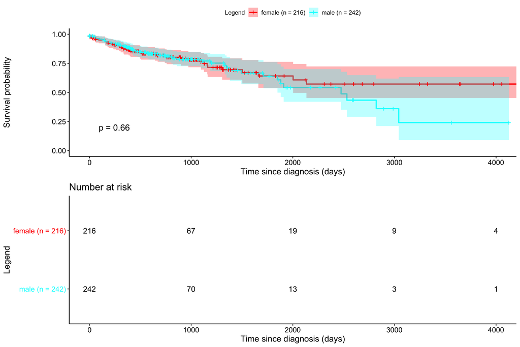